# Analysis of Red Wine Data by Ryan Galvin

# Univariate Analysis

### What is/are the main feature(s) of interest in your dataset?

> The main features of interest in this dataset are the relationships between each chemical property and the quality of the wine.

### What other features in the dataset do you think will help support your investigation into your feature(s) of interest?

> I will look into relationships between the input variables, and see for example whether or not the normally distributed variables have stronger correlation to quality of red wine over the non-normal distributions.

# Bivariate Plots Section

> I would like to look at the relationship between total and free sulfur dioxide, fixed and volatile acidity, and all of these vs. quality to start.

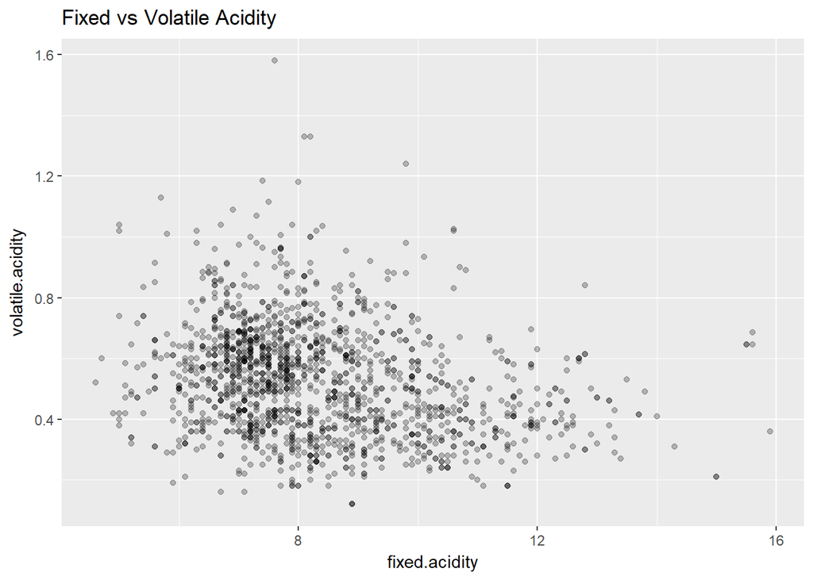

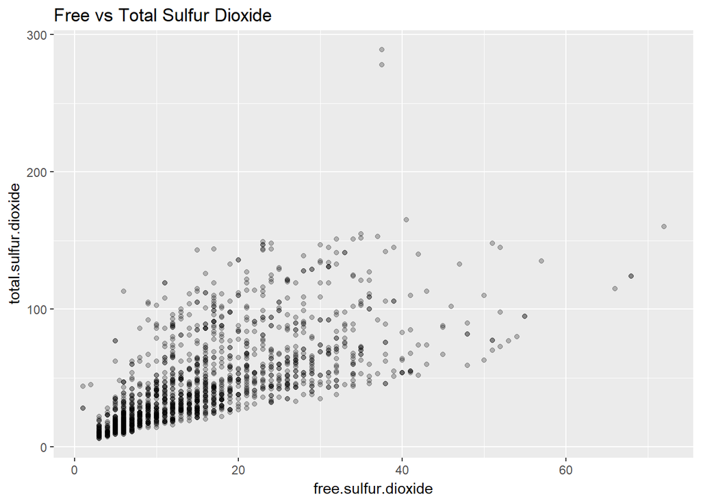

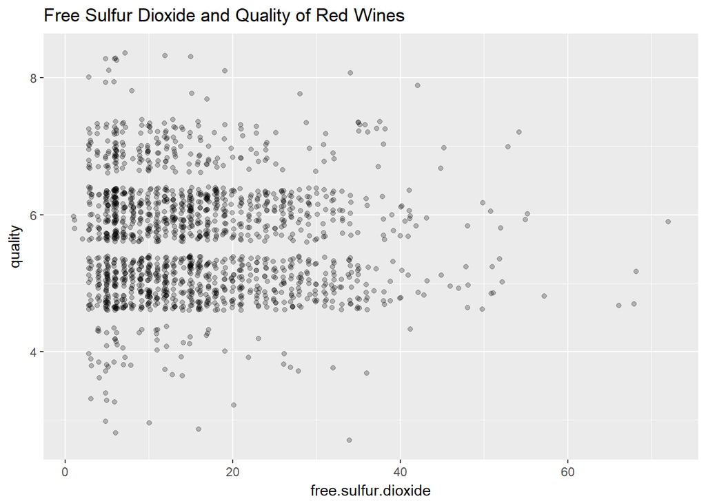

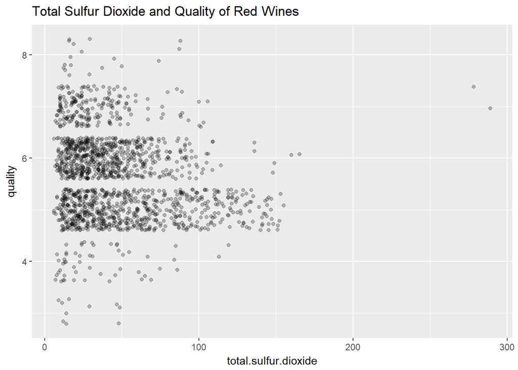

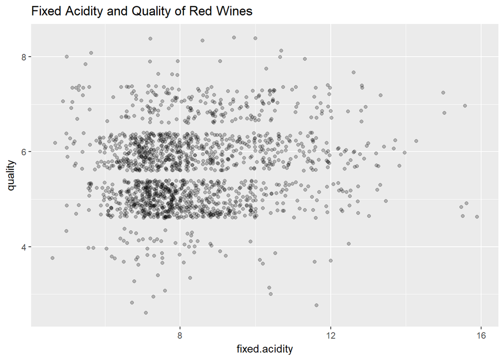

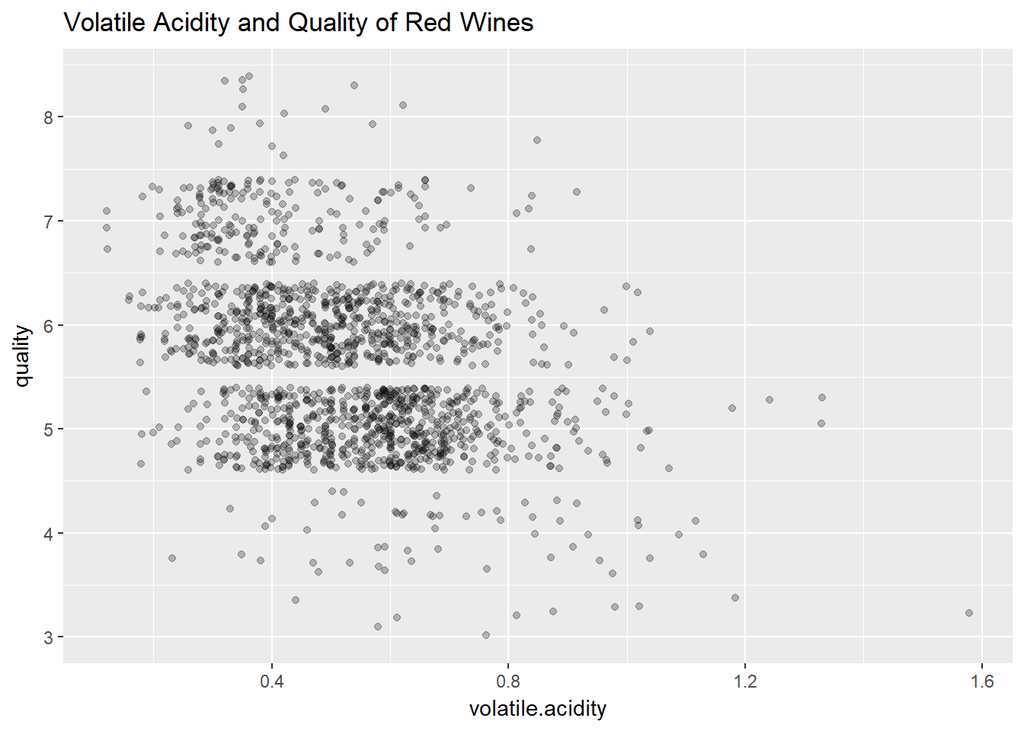

# Bivariate Analysis

### Talk about some of the relationships you observed in this part of the investigation. How did the feature(s) of interest vary with other features in the dataset?

> When we look at fixed acidity vs. volatile acidity, we don’t see much of a relationship at all. Most wines have a fixed acidity around 8, and a volatile acidity between 0.4 and 0.8.

> However, we can see as free sulfur dioxide increases, total sulfur dioxide increases, which makes sense.

> Out of all of the quality plots, it looks like the features most likely to have a high quality wine rating are free sulfur dioxide and fixed acidity.

### Did you observe any interesting relationships between the other features (not the main feature(s) of interest)?

> The most interesting feature observed was that fixed acidity and volatile acidity have almost no correlation together.

### What was the strongest relationship you found?

> The strongest relationship I found was free sulfur dioxide to total sulfur dioxide, which has a pretty obvious linear monotonic relationship.

# Multivariate Plots Section

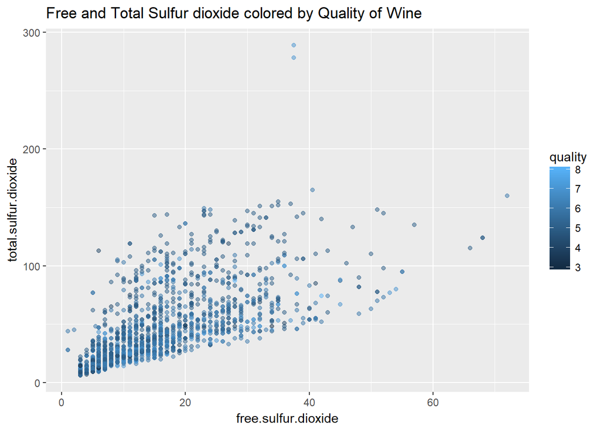

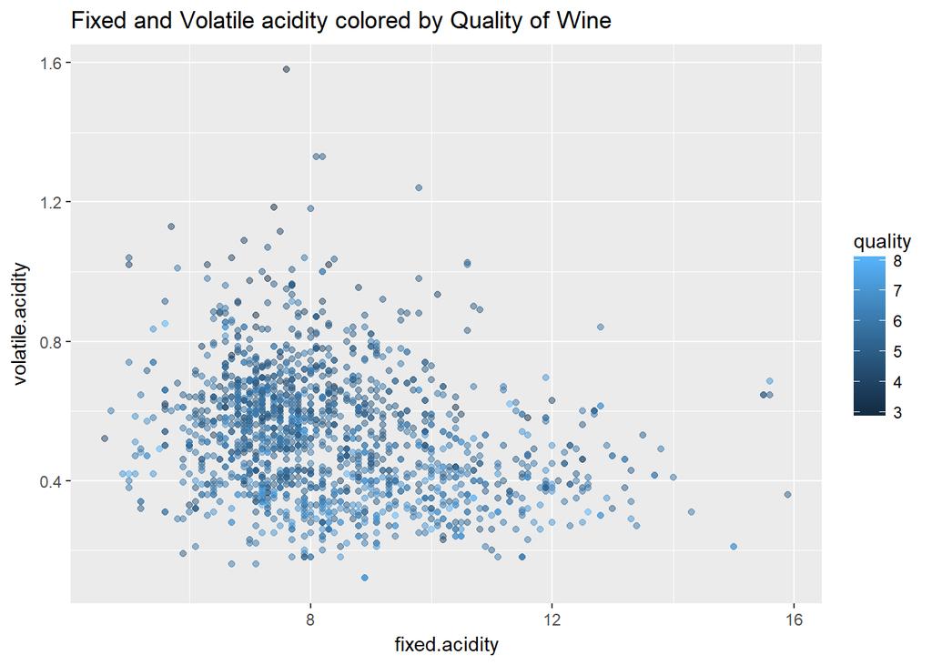

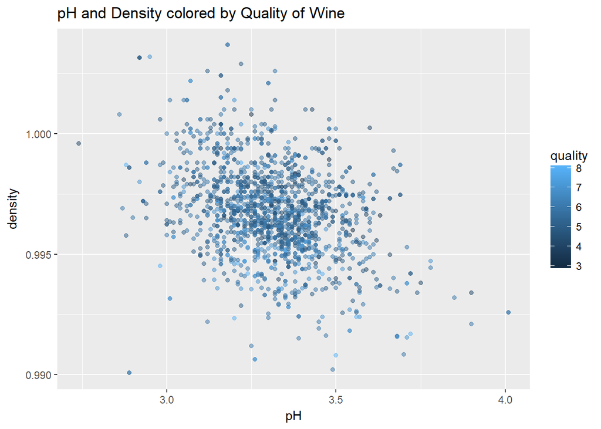

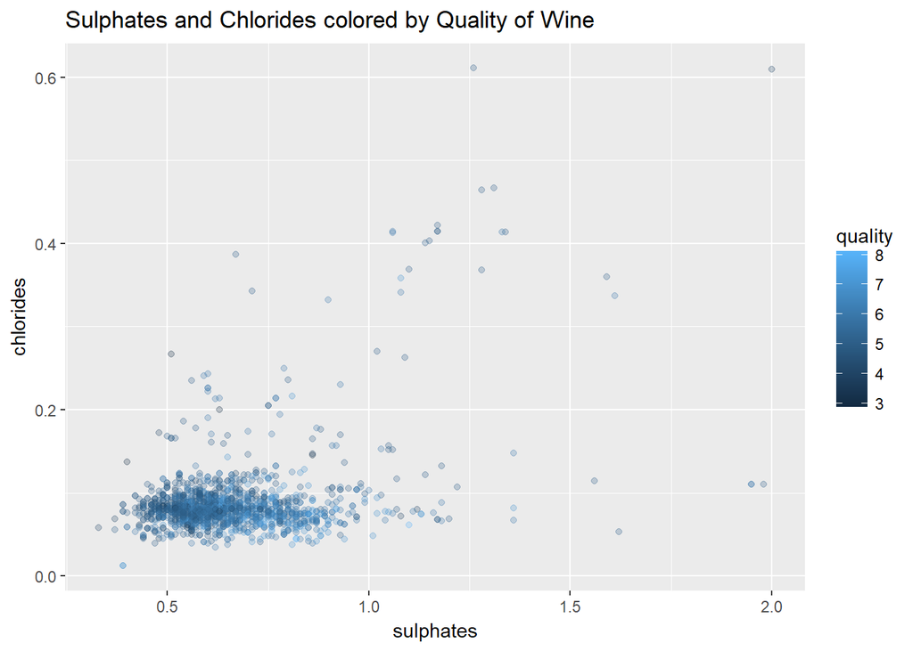

# Multivariate Analysis

### Talk about some of the relationships you observed in this part of the investigation. Were there features that strengthened each other in terms of looking at your feature(s) of interest?

> I looked at quality alongside my scatterplots of fixed and volatile acidity, and free and total sulfur dioxide. I found that higher quality wines tend to have lower free and total sulfur dioxide both, and also that higher quality wines tend to have lower volatile acidity, but don’t really follow any sort of pattern for fixed acidity.

> I also decided to examine pH and Density as I thought it was interesting they were both roughly normally distributed. Higher quality wines tend to be a bit lower on the dense side, with most wines falling in the dead center of the pH and density scatterplot.

> I finally looked at chlorides and sulphates together colored by quality, and found that chlorides stay roughly the same for most wines, although with Sulphates, we see a variance in the quality of wine for slightly higher sulphates than lower sulphates.

### Were there any interesting or surprising interactions between features?

> I was surprised to see that fixed acidity could not be fit to any sort of pattern for quality, but volatile acidity could.

# Final Plots and Summary

### Plot One

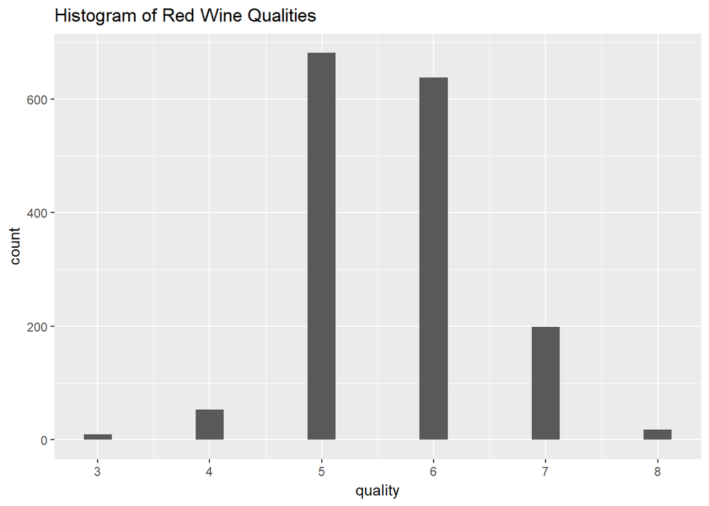

### Description One

> I choose to include the quality histogram so we can see where most wine quality falls, and thus be better able to interpret what would be considered a generally “high” quality of wine. We could say 6 and 7 are high enough quality wines for this data, given how few wines are rated an 8.

### Plot Two

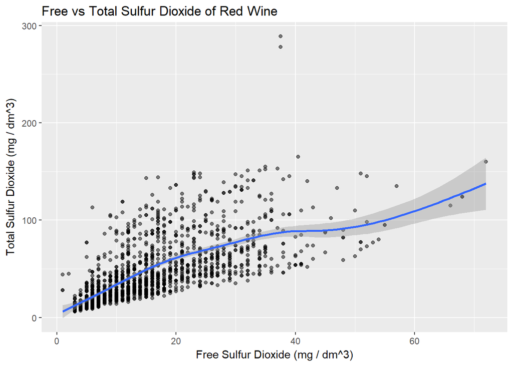

### Description Two

> I include this scatterplot between free and total sulfur dioxide because I found the near linear relationship between them interesting, although expected.

### Plot Three

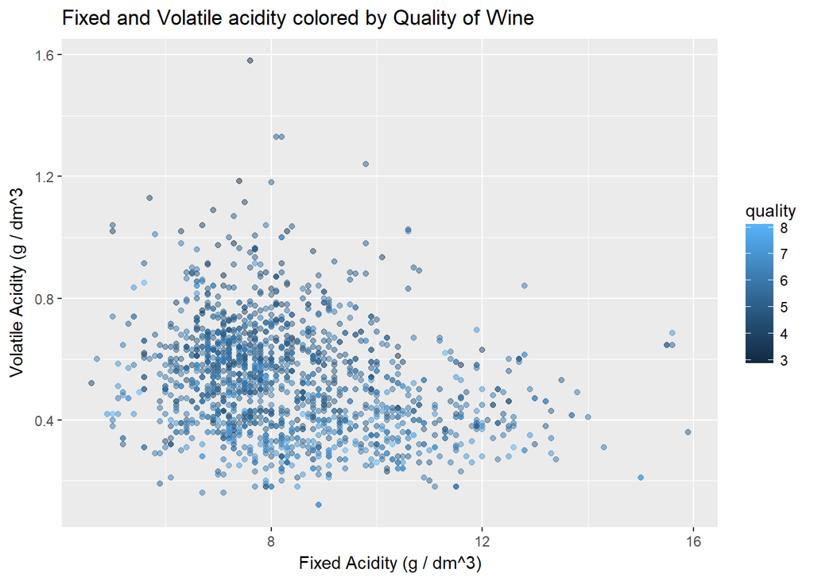

# Reflection

> This red wine dataset has a lot of room for further exploration; I only initialled looked into sections that I found interesting. We could look at the other variables I didn’t assess like sugar, citric acid, alcohol and more.